# Part II - Prosper Loan Data Findings

## by Olaniyan Daniel Olusegun

## Investigation Overview

> In this investigation, I wanted to look at the characteristics of loans that could be used to predict their borrower APR. The main focus was on the borrower's Prosper rating, loan Term, Estimated Loss and Estimatted Return.

## Dataset Overview

> This document explores a datas, et containing borrower's APR and attributes (such as Proper Rating, Loan Term, Estimated Loss, Estimatted Return and many others) for approximately 113937 loans.

## Distribution of Borrower APR

> The distribution of APR looks multimodal. A small peak centered at 0.09, a large peak centered at 0.18. There is also a small peak centered 0.29. Additionally, there is a very sharp peak between 0.35 and 0.36. Only very few loans have APR greater than 0.41.

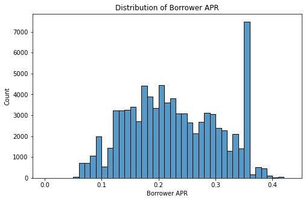

## Distribution of Loan Status

> The highest loan status is Current, followed by Completed then Chargedoff

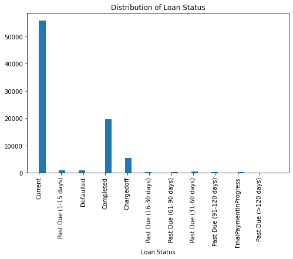

## Borrower APR vs. Prosper Rating

> The borrower APR decreases with the better rating. Borrowers with the best Prosper ratings have the lowest APR. It means that the Prosper rating has a strong effect on borrower APR.

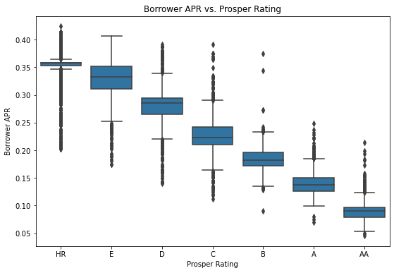

## Prosper Rating Effect on Relationship between APR and Estimated Return

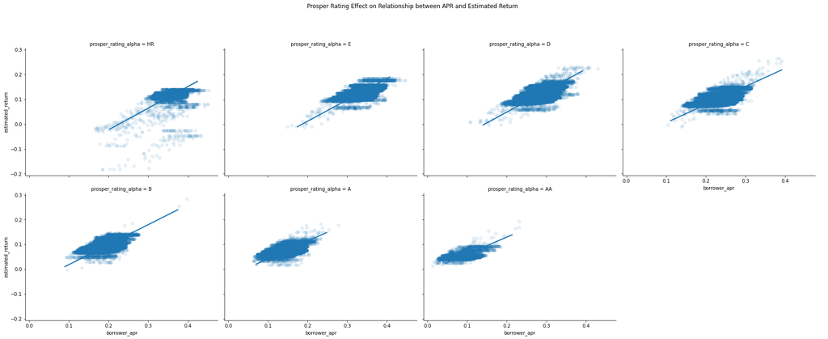

## Borrower APR by Rating and Term

Interestingly, the borrower APR decrease with the increase of borrow term for people with HR-C raings. But for people with B-AA ratings, the APR increase with the increase of borrow term.

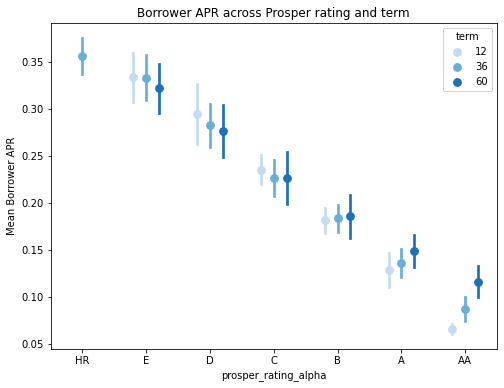